# Bellabeat - Data Analysis

2023-03-06

# Introduction

Bellabeat in recent years expanded throughout the world, opening new offices and launching multiple products. Growing e-commerce market brought new opportunities to reach more customers than ever, so naturally to make most of it, new marketing strategies were developed. Bellabeat has not only invested in traditional advertising media, but also focused on digital marketing. As a high-tech company that manufactures health-focused smart products, Bellabeat gathers huge amounts of data about it’s customers that can be used to optimize current marketing and product development strategy.

# 1 Ask Phase

## 1.1 What is the business task?

The goal of this analysis is to identify and provide insights on trends within data that explores smart device users’ daily habits, which will hopefully help with development and execution of marketing strategies.

## 1.2 Who are the Key Stakeholders?

Urška Sršen - Bellabeat cofounder and Chief Creative Officer

Sando Mur - Bellabeat cofounder and key member of Bellabeat executive team

Bellabeat Marketing Analytics team

# 2 Prepare Phase

## 2.1 Source

[FitBit Fitness Tracker Data](https://www.kaggle.com/datasets/arashnic/fitbit) was made available by [Mosbius](https://www.kaggle.com/arashnic) (CC0: Public Domain).

## 2.2 Contents and Privacy

This dataset generated by respondents to a distributed survey via Amazon Mechanical Turk between 03.12.2016-05.12.2016. Thirty eligible Fitbit users consented to the submission of personal tracker data, including minute-level output for physical activity, heart rate, and sleep monitoring. Individual reports can be parsed by export session ID (column A) or timestamp (column B). Variation between output represents use of different types of Fitbit trackers and individual tracking behaviors / preferences.

## 2.3 Data Credibility and Integrity

Data to be used has several limitations, that need to be considered during analysis, such as:

- limited sample size (30 users) can be not reflective of the whole population;
- no information on the demographic can lead to potential bias and/or conclusions not applicable for Bellabeat targeted users; and
- presented data is not recent and covers only 2 months of measurements which can be not reflective of the overarching trends throughout the year.

## 2.4 Storage

All of the data files this analysis is based on can be found [here] (in real scenario path would be linked).

## 2.2 Selected datasets

For this analysis I will focus on data sets measuring:

- daily activity;
- hourly steps; and
- daily sleep.

Due to the the small sample we won’t consider for this analysis Weight (8 Users) and heart rate (7 users).

# 3 Process Phase

In this analysis I will focus on R for shareability and to be able to create data visualiztion for the stakeholders.

## 3.1 Installing and loading the packages

```r
library(tidyverse)
library(here)
library(lubridate)
library(janitor)
library(tidyr)
library(dplyr)
library(ggpubr)
library(ggrepel)
```

## 3.2 Importing dataset

```r
daily_activity <- read_csv("dailyActivity_merged.csv")
daily_sleep <- read_csv("sleepDay_merged.csv")
hourly_steps <- read_csv("hourlySteps_merged.csv")
```

## 3.3 Previewing the data

```r
head(daily_activity)
```

```
## # A tibble: 6 × 15
##       Id Activ…¹ Total…² Total…³ Track…⁴ Logge…⁵ VeryA…⁶ Moder…⁷ Light…⁸ Seden…⁹
##    <dbl> <chr>     <dbl>   <dbl>   <dbl>   <dbl>   <dbl>   <dbl>   <dbl>   <dbl>
## 1 1.50e9 4/12/2…   13162    8.5     8.5        0    1.88   0.550    6.06       0
## 2 1.50e9 4/13/2…   10735    6.97    6.97       0    1.57   0.690    4.71       0
## 3 1.50e9 4/14/2…   10460    6.74    6.74       0    2.44   0.400    3.91       0
## 4 1.50e9 4/15/2…    9762    6.28    6.28       0    2.14   1.26     2.83       0
## 5 1.50e9 4/16/2…   12669    8.16    8.16       0    2.71   0.410    5.04       0
## 6 1.50e9 4/17/2…    9705    6.48    6.48       0    3.19   0.780    2.51       0
## # … with 5 more variables: VeryActiveMinutes <dbl>, FairlyActiveMinutes <dbl>,
## #   LightlyActiveMinutes <dbl>, SedentaryMinutes <dbl>, Calories <dbl>, and
## #   abbreviated variable names ¹ActivityDate, ²TotalSteps, ³TotalDistance,
## #   ⁴TrackerDistance, ⁵LoggedActivitiesDistance, ⁶VeryActiveDistance,
## #   ⁷ModeratelyActiveDistance, ⁸LightActiveDistance, ⁹SedentaryActiveDistance
```

```r
str(daily_activity)
```

```
## spc_tbl_ [940 × 15] (S3: spec_tbl_df/tbl_df/tbl/data.frame)
##  $ Id                      : num [1:940] 1.5e+09 1.5e+09 1.5e+09 1.5e+09 1.5e+09 ...
##  $ ActivityDate            : chr [1:940] "4/12/2016" "4/13/2016" "4/14/2016" "4/15/2016" ...
##  $ TotalSteps              : num [1:940] 13162 10735 10460 9762 12669 ...
##  $ TotalDistance           : num [1:940] 8.5 6.97 6.74 6.28 8.16 ...
##  $ TrackerDistance         : num [1:940] 8.5 6.97 6.74 6.28 8.16 ...
##  $ LoggedActivitiesDistance: num [1:940] 0 0 0 0 0 0 0 0 0 0 ...
##  $ VeryActiveDistance      : num [1:940] 1.88 1.57 2.44 2.14 2.71 ...
##  $ ModeratelyActiveDistance: num [1:940] 0.55 0.69 0.4 1.26 0.41 ...
##  $ LightActiveDistance     : num [1:940] 6.06 4.71 3.91 2.83 5.04 ...
##  $ SedentaryActiveDistance : num [1:940] 0 0 0 0 0 0 0 0 0 0 ...
##  $ VeryActiveMinutes       : num [1:940] 25 21 30 29 36 38 42 50 28 19 ...
##  $ FairlyActiveMinutes     : num [1:940] 13 19 11 34 10 20 16 31 12 8 ...
##  $ LightlyActiveMinutes    : num [1:940] 328 217 181 209 221 164 233 264 205 211 ...
##  $ SedentaryMinutes        : num [1:940] 728 776 1218 726 773 ...
##  $ Calories                : num [1:940] 1985 1797 1776 1745 1863 ...
##  - attr(*, "spec")=
##   .. cols(
##   ..   Id = col_double(),
##   ..   ActivityDate = col_character(),
##   ..   TotalSteps = col_double(),
##   ..   TotalDistance = col_double(),
##   ..   TrackerDistance = col_double(),
##   ..   LoggedActivitiesDistance = col_double(),
##   ..   VeryActiveDistance = col_double(),
##   ..   ModeratelyActiveDistance = col_double(),
##   ..   LightActiveDistance = col_double(),
##   ..   SedentaryActiveDistance = col_double(),
##   ..   VeryActiveMinutes = col_double(),
##   ..   FairlyActiveMinutes = col_double(),
##   ..   LightlyActiveMinutes = col_double(),
##   ..   SedentaryMinutes = col_double(),
##   ..   Calories = col_double()
##   .. )
##  - attr(*, "problems")=<externalptr>
```

```r
head(hourly_steps)
```

```
## # A tibble: 6 × 3
##           Id ActivityHour          StepTotal
##        <dbl> <chr>                     <dbl>
## 1 1503960366 4/12/2016 12:00:00 AM       373
## 2 1503960366 4/12/2016 1:00:00 AM        160
## 3 1503960366 4/12/2016 2:00:00 AM        151
## 4 1503960366 4/12/2016 3:00:00 AM          0
## 5 1503960366 4/12/2016 4:00:00 AM          0
## 6 1503960366 4/12/2016 5:00:00 AM          0
```

```r
str(hourly_steps)
```

```
## spc_tbl_ [22,099 × 3] (S3: spec_tbl_df/tbl_df/tbl/data.frame)
##  $ Id          : num [1:22099] 1.5e+09 1.5e+09 1.5e+09 1.5e+09 1.5e+09 ...
##  $ ActivityHour: chr [1:22099] "4/12/2016 12:00:00 AM" "4/12/2016 1:00:00 AM" "4/12/2016 2:00:00 AM" "4/12/2016 3:00:00 AM" ...
##  $ StepTotal   : num [1:22099] 373 160 151 0 0 ...
##  - attr(*, "spec")=
##   .. cols(
##   ..   Id = col_double(),
##   ..   ActivityHour = col_character(),
##   ..   StepTotal = col_double()
##   .. )
##  - attr(*, "problems")=<externalptr>
```

```r
head(daily_sleep)
```

```
## # A tibble: 6 × 5
##           Id SleepDay              TotalSleepRecords TotalMinutesAsleep TotalT…¹
##        <dbl> <chr>                             <dbl>              <dbl>    <dbl>
## 1 1503960366 4/12/2016 12:00:00 AM                 1                327      346
## 2 1503960366 4/13/2016 12:00:00 AM                 2                384      407
## 3 1503960366 4/15/2016 12:00:00 AM                 1                412      442
## 4 1503960366 4/16/2016 12:00:00 AM                 2                340      367
## 5 1503960366 4/17/2016 12:00:00 AM                 1                700      712
## 6 1503960366 4/19/2016 12:00:00 AM                 1                304      320
## # … with abbreviated variable name ¹TotalTimeInBed
```

```r
str(daily_sleep)
```

```
## spc_tbl_ [413 × 5] (S3: spec_tbl_df/tbl_df/tbl/data.frame)
##  $ Id                : num [1:413] 1.5e+09 1.5e+09 1.5e+09 1.5e+09 1.5e+09 ...
##  $ SleepDay          : chr [1:413] "4/12/2016 12:00:00 AM" "4/13/2016 12:00:00 AM" "4/15/2016 12:00:00 AM" "4/16/2016 12:00:00 AM" ...
##  $ TotalSleepRecords : num [1:413] 1 2 1 2 1 1 1 1 1 1 ...
##  $ TotalMinutesAsleep: num [1:413] 327 384 412 340 700 304 360 325 361 430 ...
##  $ TotalTimeInBed    : num [1:413] 346 407 442 367 712 320 377 364 384 449 ...
##  - attr(*, "spec")=
##   .. cols(
##   ..   Id = col_double(),
##   ..   SleepDay = col_character(),
##   ..   TotalSleepRecords = col_double(),
##   ..   TotalMinutesAsleep = col_double(),
##   ..   TotalTimeInBed = col_double()
##   .. )
##  - attr(*, "problems")=<externalptr>
```

## 3.4 Cleaning and Formating

As we got accustomed with the format of the data, it is time to remove any errors and inconsistencies.

### 3.4.1 Number of unique users

Before we continue with our cleaning we want to make sure how many unique users are per data frame. Even though 30 is the minimal sample size we will still keep the sleep dataset for practice only.

```r
n_distinct(daily_activity$Id)
```

```
## [1] 33
```

```r
n_distinct(hourly_steps$Id)
```

```
## [1] 33
```

```r
n_distinct(daily_sleep$Id)
```

```
## [1] 24
```

### 3.4.2 Identify Duplicates

```r
sum(duplicated(daily_activity))
```

```
## [1] 0
```

```r
sum(duplicated(daily_sleep))
```

```
## [1] 3
```

```r
sum(duplicated(hourly_steps))
```

```
## [1] 0
```

### 3.4.3 Remove duplicates and N/A

```r
daily_activity <- daily_activity %>%
  distinct() %>%
  drop_na()

daily_sleep <- daily_sleep %>%
  distinct() %>%
  drop_na()

hourly_steps <- hourly_steps %>%
  distinct() %>%
  drop_na()
```

Check if duplicates were removed from the sleep data

```r
sum(duplicated(daily_sleep))
```

```
## [1] 0
```

### 3.4.4 Clean and rename columns

For the sake of clarity and later merging of the data frames, we will ensure coherent naming system by using correct syntax and changing everything to lowercase.

```r
clean_names(daily_activity)
```

```
## # A tibble: 940 × 15
##            id activity…¹ total…² total…³ track…⁴ logge…⁵ very_…⁶ moder…⁷ light…⁸
##         <dbl> <chr>        <dbl>   <dbl>   <dbl>   <dbl>   <dbl>   <dbl>   <dbl>
##  1 1503960366 4/12/2016    13162    8.5     8.5        0    1.88   0.550    6.06
##  2 1503960366 4/13/2016    10735    6.97    6.97       0    1.57   0.690    4.71
##  3 1503960366 4/14/2016    10460    6.74    6.74       0    2.44   0.400    3.91
##  4 1503960366 4/15/2016     9762    6.28    6.28       0    2.14   1.26     2.83
##  5 1503960366 4/16/2016    12669    8.16    8.16       0    2.71   0.410    5.04
##  6 1503960366 4/17/2016     9705    6.48    6.48       0    3.19   0.780    2.51
##  7 1503960366 4/18/2016    13019    8.59    8.59       0    3.25   0.640    4.71
##  8 1503960366 4/19/2016    15506    9.88    9.88       0    3.53   1.32     5.03
##  9 1503960366 4/20/2016    10544    6.68    6.68       0    1.96   0.480    4.24
## 10 1503960366 4/21/2016     9819    6.34    6.34       0    1.34   0.350    4.65
## # … with 930 more rows, 6 more variables: sedentary_active_distance <dbl>,
## #   very_active_minutes <dbl>, fairly_active_minutes <dbl>,
## #   lightly_active_minutes <dbl>, sedentary_minutes <dbl>, calories <dbl>, and
## #   abbreviated variable names ¹activity_date, ²total_steps, ³total_distance,
## #   ⁴tracker_distance, ⁵logged_activities_distance, ⁶very_active_distance,
## #   ⁷moderately_active_distance, ⁸light_active_distance
```

```r
daily_activity <- rename_with(daily_activity, tolower)
clean_names(daily_sleep)
```

```
## # A tibble: 410 × 5
##            id sleep_day             total_sleep_records total_minutes_…¹ total…²
##         <dbl> <chr>                               <dbl>            <dbl>   <dbl>
##  1 1503960366 4/12/2016 12:00:00 AM                   1              327     346
##  2 1503960366 4/13/2016 12:00:00 AM                   2              384     407
##  3 1503960366 4/15/2016 12:00:00 AM                   1              412     442
##  4 1503960366 4/16/2016 12:00:00 AM                   2              340     367
##  5 1503960366 4/17/2016 12:00:00 AM                   1              700     712
##  6 1503960366 4/19/2016 12:00:00 AM                   1              304     320
##  7 1503960366 4/20/2016 12:00:00 AM                   1              360     377
##  8 1503960366 4/21/2016 12:00:00 AM                   1              325     364
##  9 1503960366 4/23/2016 12:00:00 AM                   1              361     384
## 10 1503960366 4/24/2016 12:00:00 AM                   1              430     449
## # … with 400 more rows, and abbreviated variable names ¹total_minutes_asleep,
## #   ²total_time_in_bed
```

```r
daily_sleep <- rename_with(daily_sleep, tolower)
clean_names(hourly_steps)
```

```
## # A tibble: 22,099 × 3
##            id activity_hour         step_total
##         <dbl> <chr>                      <dbl>
##  1 1503960366 4/12/2016 12:00:00 AM        373
##  2 1503960366 4/12/2016 1:00:00 AM         160
##  3 1503960366 4/12/2016 2:00:00 AM         151
##  4 1503960366 4/12/2016 3:00:00 AM           0
##  5 1503960366 4/12/2016 4:00:00 AM           0
##  6 1503960366 4/12/2016 5:00:00 AM           0
##  7 1503960366 4/12/2016 6:00:00 AM           0
##  8 1503960366 4/12/2016 7:00:00 AM           0
##  9 1503960366 4/12/2016 8:00:00 AM         250
## 10 1503960366 4/12/2016 9:00:00 AM        1864
## # … with 22,089 more rows
```

```r
hourly_steps <- rename_with(hourly_steps, tolower)
```

### 3.4.5 Setting consitstent date format

Now we need to set the same date format for for daily_activity and daily_sleep so we can marge them later.

```r
daily_activity <- daily_activity %>%
  rename(date = activitydate) %>%
  mutate(date = as_date(date, format = "%m/%d/%Y"))
daily_sleep <- daily_sleep %>%
  rename(date = sleepday) %>%
  mutate(date = as_date(date, format = "%m/%d/%Y %I:%M:%S %p"))
```

For coherent naming convention and format, we will also change hourly_steps data frame.

```r
hourly_steps<- hourly_steps %>%
  rename(date_time = activityhour) %>%
  mutate(date_time = as.POSIXct(date_time,format ="%m/%d/%Y %I:%M:%S %p"))
```

## 3.5 Merging datasets

As daily_sleep and daily activity measurements cover the same time periods, we can merge them to see any correlations using Id and date as primary keys

```r
daily_activity_sleep <- merge(daily_activity, daily_sleep, by=c("id", "date"))

glimpse(daily_activity_sleep)
```

```
## Rows: 410
## Columns: 18
## $ id                       <dbl> 1503960366, 1503960366, 1503960366, 150396036…
## $ date                     <date> 2016-04-12, 2016-04-13, 2016-04-15, 2016-04-…
## $ totalsteps               <dbl> 13162, 10735, 9762, 12669, 9705, 15506, 10544…
## $ totaldistance            <dbl> 8.50, 6.97, 6.28, 8.16, 6.48, 9.88, 6.68, 6.3…
## $ trackerdistance          <dbl> 8.50, 6.97, 6.28, 8.16, 6.48, 9.88, 6.68, 6.3…
## $ loggedactivitiesdistance <dbl> 0, 0, 0, 0, 0, 0, 0, 0, 0, 0, 0, 0, 0, 0, 0, …
## $ veryactivedistance       <dbl> 1.88, 1.57, 2.14, 2.71, 3.19, 3.53, 1.96, 1.3…
## $ moderatelyactivedistance <dbl> 0.55, 0.69, 1.26, 0.41, 0.78, 1.32, 0.48, 0.3…
## $ lightactivedistance      <dbl> 6.06, 4.71, 2.83, 5.04, 2.51, 5.03, 4.24, 4.6…
## $ sedentaryactivedistance  <dbl> 0, 0, 0, 0, 0, 0, 0, 0, 0, 0, 0, 0, 0, 0, 0, …
## $ veryactiveminutes        <dbl> 25, 21, 29, 36, 38, 50, 28, 19, 41, 39, 73, 3…
## $ fairlyactiveminutes      <dbl> 13, 19, 34, 10, 20, 31, 12, 8, 21, 5, 14, 23,…
## $ lightlyactiveminutes     <dbl> 328, 217, 209, 221, 164, 264, 205, 211, 262, …
## $ sedentaryminutes         <dbl> 728, 776, 726, 773, 539, 775, 818, 838, 732, …
## $ calories                 <dbl> 1985, 1797, 1745, 1863, 1728, 2035, 1786, 177…
## $ totalsleeprecords        <dbl> 1, 2, 1, 2, 1, 1, 1, 1, 1, 1, 1, 1, 1, 1, 1, …
## $ totalminutesasleep       <dbl> 327, 384, 412, 340, 700, 304, 360, 325, 361, …
## $ totaltimeinbed           <dbl> 346, 407, 442, 367, 712, 320, 377, 364, 384, …
```

# 4 Analysis Phase

We will analyze trends of the users of FitBit and determine if that can help us on BellaBeat’s marketing strategy

## 4.1 Type of users per activity level

No data on demographic force us to create our own user groups based on data we have. First distinction will be made by measuring average activity levels based on steps made a day.

For reference we will use categorization provided by CQUniversity Australia which can be found [here](https://www.10000steps.org.au/articles/healthy-lifestyles/counting-steps/). It establishes 5 levels of activity:

- Sedentary is less than 5,000 steps per day;
- Low active is 5,000 to 7,499 steps per day;
- Fairly active is 7,500 to 9,999 steps per day;
- Active is more than 10,000 steps per day;
- Highly active is more than 12,500 .

First, we need to calculate daily averages (steps, sleep calories) per user.

```r
daily_average <- daily_activity_sleep %>%
  group_by(id) %>%
  summarise(avg_steps = mean(totalsteps), avg_sleep = mean(totalminutesasleep), avg_calories = mean(calories))

head(daily_average)
```

```
## # A tibble: 6 × 4
##           id avg_steps avg_sleep avg_calories
##        <dbl>     <dbl>     <dbl>        <dbl>
## 1 1503960366    12406.      360.        1872.
## 2 1644430081     7968.      294         2978.
## 3 1844505072     3477       652         1676.
## 4 1927972279     1490       417         2316.
## 5 2026352035     5619.      506.        1541.
## 6 2320127002     5079        61         1804
```

Now we can assign activity level to a user based on his average steps per day.

```r
user_type <- daily_average %>%
  mutate(user_type = case_when(
   avg_steps < 5000 ~ "sedentary",
   avg_steps >= 5000 & avg_steps < 7500 ~ "lightly_active",
   avg_steps >= 7500 & avg_steps < 10000 ~ "fairly_active",
   avg_steps >= 10000 & avg_steps < 12500 ~ "active",
   avg_steps >= 12500 ~ "highly_active"
  ))

head(user_type)
```

```
## # A tibble: 6 × 5
##           id avg_steps avg_sleep avg_calories user_type
##        <dbl>     <dbl>     <dbl>        <dbl> <chr>
## 1 1503960366    12406.      360.        1872. active
## 2 1644430081     7968.      294         2978. fairly_active
## 3 1844505072     3477       652         1676. sedentary
## 4 1927972279     1490       417         2316. sedentary
## 5 2026352035     5619.      506.        1541. lightly_active
## 6 2320127002     5079        61         1804  lightly_active
```

To help visualize data, we will assign percentages to each user type representing their participation in the population, and then we will present them on the pie chart.

```r
user_type_percentage <- user_type %>%
  group_by(user_type) %>%
  summarise(total = n()) %>%
  mutate(totals = sum(total)) %>%
  group_by(user_type) %>%
  summarise(total_percent = total / totals) %>%
  mutate(labels = scales::percent(total_percent))

user_type_percentage$user_type <- factor(user_type_percentage$user_type , levels = c("highly_active", "active", "fairly_active", "lightly_active", "sedentary"))

head(user_type_percentage)
```

```
## # A tibble: 5 × 3
##   user_type      total_percent labels
##   <fct>                  <dbl> <chr>
## 1 active                0.167  16.7%
## 2 fairly_active         0.375  37.5%
## 3 highly_active         0.0417 4.2%
## 4 lightly_active        0.208  20.8%
## 5 sedentary             0.208  20.8%
```

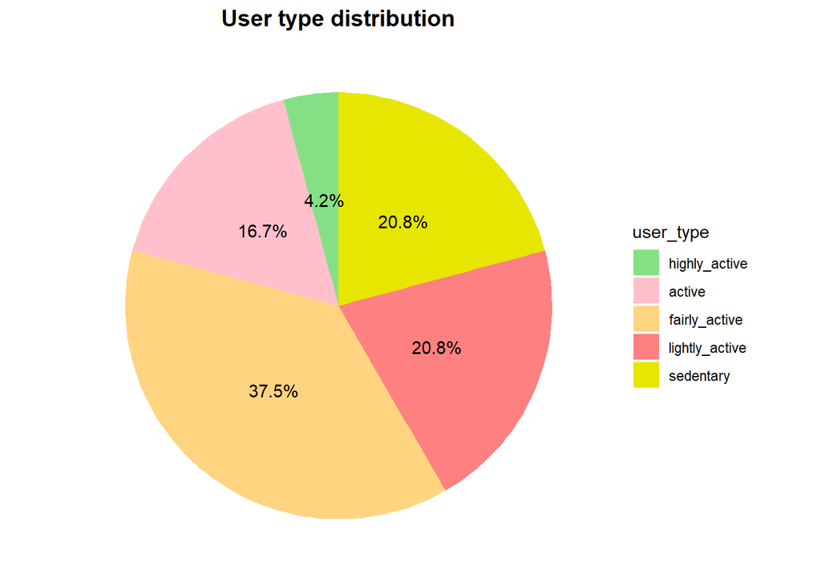

```r
user_type_percentage %>%
  ggplot(aes(x="", y=total_percent, fill=user_type))+
  geom_bar(stat="identity", width=1)+
  coord_polar("y", start=0)+
  theme_minimal()+
  theme(axis.title.x= element_blank(),
        axis.title.y = element_blank(),
        panel.border = element_blank(),
        panel.grid = element_blank(),
        axis.ticks = element_blank(),
        axis.text.x = element_blank(),
        plot.title = element_text(hjust = 0.5, size=14, face = "bold")) +
  scale_fill_manual(values = c("#85e085","pink", "#ffd480", "#ff8080", "#e6e600")) +
   geom_text(aes(label = labels),
position = position_stack(vjust = 0.5))+
  labs(title="User type distribution")
```

## 4.2 Steps and minutes asleep per weekday

To better understand how user activity and sleep looks throughout the week, we will create new data frame and then put it into chart.

```r
Sys.setlocale("LC_TIME","English_United States.1252")
```

```
## [1] "English_United States.1252"
```

```r
weekday_steps_sleep <- daily_activity_sleep %>%
  mutate(weekday = weekdays(date))

weekday_steps_sleep$weekday <-ordered(weekday_steps_sleep$weekday, levels=c("Monday", "Tuesday", "Wednesday", "Thursday",
"Friday", "Saturday", "Sunday"))

 weekday_steps_sleep <-weekday_steps_sleep%>%
  group_by(weekday) %>%
  summarize (daily_steps = mean(totalsteps), daily_sleep = mean(totalminutesasleep))

head(weekday_steps_sleep)
```

```
## # A tibble: 6 × 3
##   weekday   daily_steps daily_sleep
##   <ord>           <dbl>       <dbl>
## 1 Monday          9273.        420.
## 2 Tuesday         9183.        405.
## 3 Wednesday       8023.        435.
## 4 Thursday        8184.        401.
## 5 Friday          7901.        405.
## 6 Saturday        9871.        419.
```

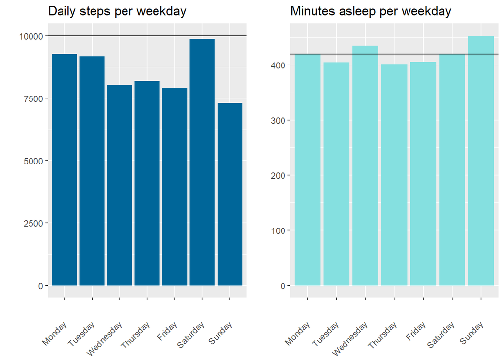

```r
ggarrange(
    ggplot(weekday_steps_sleep) +
      geom_col(aes(weekday, daily_steps), fill = "#006699") +
      geom_hline(yintercept = 10000) +
      labs(title = "Daily steps per weekday", x= "", y = "") +
      theme(axis.text.x = element_text(angle = 45,vjust = 0.5, hjust = 1)),
    ggplot(weekday_steps_sleep, aes(weekday, daily_sleep)) +
      geom_col(fill = "#85e0e0") +
      geom_hline(yintercept = 420) +
      labs(title = "Minutes asleep per weekday", x= "", y = "") +
      theme(axis.text.x = element_text(angle = 45,vjust = 0.5, hjust = 1))
  )
```

## 4.3 Hourly steps throughout the day

To delve deeper into the steps topic, we will see how their spread through out the day look like.

First we will separate date_time column from hourly_steps dataset and then visualize the results.

```r
hourly_steps <- hourly_steps %>%
  separate(date_time, into = c("date", "time"), sep = " ") %>%
  mutate(date = ymd(date))

head(hourly_steps)
```

```
## # A tibble: 6 × 4
##           id date       time     steptotal
##        <dbl> <date>     <chr>        <dbl>
## 1 1503960366 2016-04-12 00:00:00       373
## 2 1503960366 2016-04-12 01:00:00       160
## 3 1503960366 2016-04-12 02:00:00       151
## 4 1503960366 2016-04-12 03:00:00         0
## 5 1503960366 2016-04-12 04:00:00         0
## 6 1503960366 2016-04-12 05:00:00         0
```

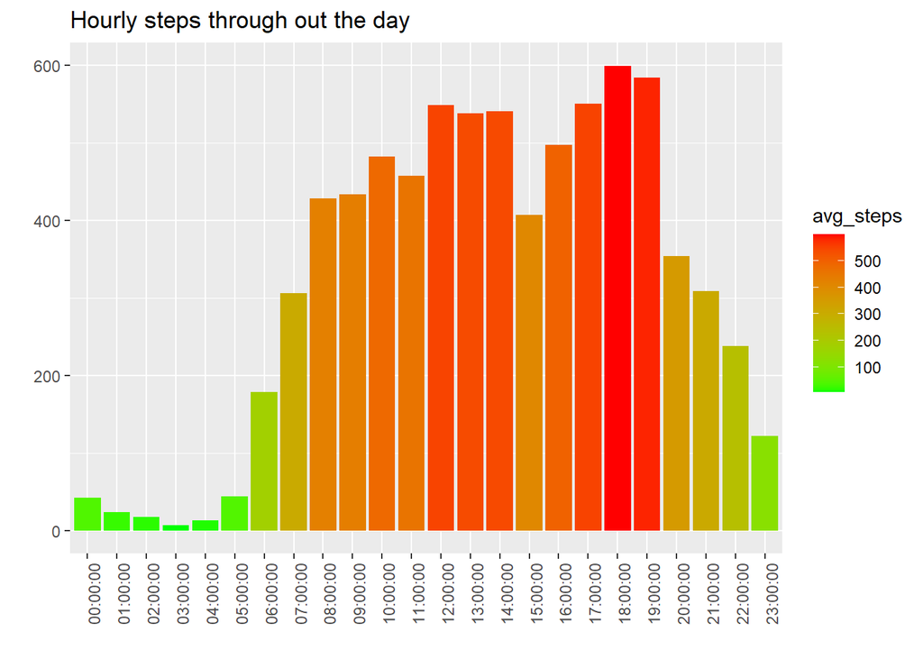

```r
hourly_steps %>%
  group_by(time) %>%
  summarize(avg_steps = mean(steptotal)) %>%
  ggplot() +
  geom_col(aes(x=time, y=avg_steps, fill = avg_steps)) +
  labs(title="Hourly steps through out the day", x="", y="") +
  scale_fill_gradient(low="green", high="red") +
  theme(axis.text.x = element_text(angle = 90))
```

## 4.4 Usage of smart devices

### 4.4.1 Day to day usage of smart devices

To see how attractive it is for users to use smart devices, we will check how many days the devices has been worn and categorize them based on the criteria provided below:

- high use - users who use their device between 21 and 31 days;
- moderate use - users who use their device between 10 and 20 days;
- low use - users who use their device between 1 and 10 days.

```r
daily_use <- daily_activity_sleep %>%
  group_by(id) %>%
  summarize(days_used = sum(n())) %>%
  mutate(usage = case_when(
    days_used >= 1 & days_used <= 10 ~ "low use",
    days_used >= 11 & days_used <= 20 ~ "moderate use",
    days_used >= 21 & days_used <= 31 ~ "high use"
  ))

head(daily_use)
```

```
## # A tibble: 6 × 3
##           id days_used usage
##        <dbl>     <int> <chr>
## 1 1503960366        25 high use
## 2 1644430081         4 low use
## 3 1844505072         3 low use
## 4 1927972279         5 low use
## 5 2026352035        28 high use
## 6 2320127002         1 low use
```

We will now put the results into percatages so that they can be better visualized using pie chart.

```r
daily_use_percentage <- daily_use %>%
  group_by(usage) %>%
  summarize(total = n()) %>%
  mutate(totals = sum(total)) %>%
  group_by(usage) %>%
  summarize(total_perctentage = total / totals) %>%
  mutate(labels=scales::percent(total_perctentage))

daily_use_percentage$usage <- factor(daily_use_percentage$usage, levels = c("high use", "moderate use", "low use"))

head(daily_use_percentage)
```

```
## # A tibble: 3 × 3
##   usage        total_perctentage labels
##   <fct>                    <dbl> <chr>
## 1 high use                 0.5   50%
## 2 low use                  0.375 38%
## 3 moderate use             0.125 12%
```

Now for the chart.

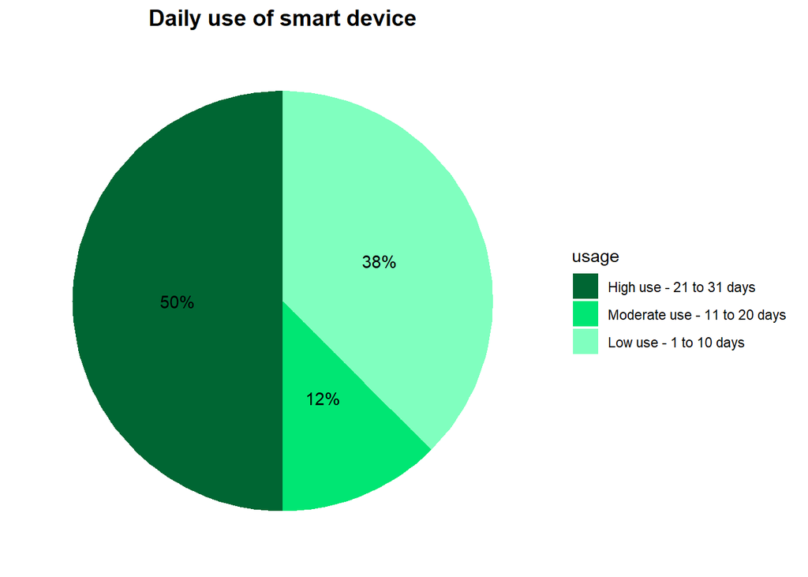

```r
daily_use_percentage %>%
  ggplot(aes(x="", y=total_perctentage, fill=usage)) +
  geom_bar(stat = "identity", width = 1)+
  coord_polar("y", start=0)+
  theme_minimal()+
  theme(axis.title.x= element_blank(),
        axis.title.y = element_blank(),
        panel.border = element_blank(),
        panel.grid = element_blank(),
        axis.ticks = element_blank(),
        axis.text.x = element_blank(),
        plot.title = element_text(hjust = 0.5, size=14, face = "bold")) +
  geom_text(aes(label = labels),
            position = position_stack(vjust = 0.5))+
  scale_fill_manual(values = c("#006633","#00e673","#80ffbf"),
                    labels = c("High use - 21 to 31 days",
                                 "Moderate use - 11 to 20 days",
                                 "Low use - 1 to 10 days"))+
  labs(title="Daily use of smart device")
```

### 4.4.2 During the day usage

To deepen our analysis, we will check how usage look like during the day. Then we will combine day to day usage results with time during the day usage results to get some insight into the users habits.

First, to be able to filter results by daily use of device, we will merge daily_activity with the daily_use data frame.

```r
daily_use_merged <- merge(daily_activity,daily_use, by=c("id"))
head(daily_use_merged)
```

```
##           id       date totalsteps totaldistance trackerdistance
## 1 1503960366 2016-05-07      11992          7.71            7.71
## 2 1503960366 2016-05-06      12159          8.03            8.03
## 3 1503960366 2016-05-01      10602          6.81            6.81
## 4 1503960366 2016-04-30      14673          9.25            9.25
## 5 1503960366 2016-04-12      13162          8.50            8.50
## 6 1503960366 2016-04-13      10735          6.97            6.97
##   loggedactivitiesdistance veryactivedistance moderatelyactivedistance
## 1                        0               2.46                     2.12
## 2                        0               1.97                     0.25
## 3                        0               2.29                     1.60
## 4                        0               3.56                     1.42
## 5                        0               1.88                     0.55
## 6                        0               1.57                     0.69
##   lightactivedistance sedentaryactivedistance veryactiveminutes
```

[output cut: 20 more lines]

Now again we will create 3 categories: - All day - device was worn all day; - More than half day - device was worn more than half of the day; - Less than half day - device was worn less than half of the day; to which we will assign user data.

```r
minutes_worn <- daily_use_merged %>%
  mutate(total_minutes_worn = veryactiveminutes+fairlyactiveminutes+lightlyactiveminutes+sedentaryminutes)%>%
  mutate (percent_minutes_worn = (total_minutes_worn/1440)*100) %>%
  mutate (worn = case_when(
    percent_minutes_worn == 100 ~ "All day",
    percent_minutes_worn < 100 & percent_minutes_worn >= 50~ "More than half day",
    percent_minutes_worn < 50 & percent_minutes_worn > 0 ~ "Less than half day"
  ))

head(minutes_worn)
```

```
##           id       date totalsteps totaldistance trackerdistance
## 1 1503960366 2016-05-07      11992          7.71            7.71
## 2 1503960366 2016-05-06      12159          8.03            8.03
## 3 1503960366 2016-05-01      10602          6.81            6.81
## 4 1503960366 2016-04-30      14673          9.25            9.25
## 5 1503960366 2016-04-12      13162          8.50            8.50
## 6 1503960366 2016-04-13      10735          6.97            6.97
##   loggedactivitiesdistance veryactivedistance moderatelyactivedistance
## 1                        0               2.46                     2.12
## 2                        0               1.97                     0.25
## 3                        0               2.29                     1.60
## 4                        0               3.56                     1.42
## 5                        0               1.88                     0.55
## 6                        0               1.57                     0.69
##   lightactivedistance sedentaryactivedistance veryactiveminutes
```

[output cut: 20 more lines]

As we have done before, to better visualize our results we will create new data frames. In this case we will create four different data frames to arrange them later on on a same visualization.

First data frame will show the total of users and will calculate percentage of minutes worn the device taking into consideration the three categories created.

The three other data frames are filtered by category of daily users so that we can see also the difference of daily use and time use.

```r
minutes_worn_percent<- minutes_worn%>%
  group_by(worn) %>%
  summarise(total = n()) %>%
  mutate(totals = sum(total)) %>%
  group_by(worn) %>%
  summarise(total_percent = total / totals) %>%
  mutate(labels = scales::percent(total_percent))


minutes_worn_highuse <- minutes_worn%>%
  filter (usage == "high use")%>%
  group_by(worn) %>%
  summarise(total = n()) %>%
  mutate(totals = sum(total)) %>%
  group_by(worn) %>%
  summarise(total_percent = total / totals) %>%
  mutate(labels = scales::percent(total_percent))

minutes_worn_moduse <- minutes_worn%>%
  filter(usage == "moderate use") %>%
  group_by(worn) %>%
  summarise(total = n()) %>%
  mutate(totals = sum(total)) %>%
  group_by(worn) %>%
  summarise(total_percent = total / totals) %>%
  mutate(labels = scales::percent(total_percent))

minutes_worn_lowuse <- minutes_worn%>%
  filter (usage == "low use") %>%
  group_by(worn) %>%
  summarise(total = n()) %>%
  mutate(totals = sum(total)) %>%
  group_by(worn) %>%
  summarise(total_percent = total / totals) %>%
  mutate(labels = scales::percent(total_percent))

minutes_worn_highuse$worn <- factor(minutes_worn_highuse$worn, levels = c("All day", "More than half day", "Less than half day"))
minutes_worn_percent$worn <- factor(minutes_worn_percent$worn, levels = c("All day", "More than half day", "Less than half day"))
minutes_worn_moduse$worn <- factor(minutes_worn_moduse$worn, levels = c("All day", "More than half day", "Less than half day"))
minutes_worn_lowuse$worn <- factor(minutes_worn_lowuse$worn, levels = c("All day", "More than half day", "Less than half day"))

head(minutes_worn_percent)
```

```
## # A tibble: 3 × 3
##   worn               total_percent labels
##   <fct>                      <dbl> <chr>
## 1 All day                   0.365  36%
## 2 Less than half day        0.0351 4%
## 3 More than half day        0.600  60%
```

```r
head(minutes_worn_highuse)
```

```
## # A tibble: 3 × 3
##   worn               total_percent labels
##   <fct>                      <dbl> <chr>
## 1 All day                   0.0676 6.8%
## 2 Less than half day        0.0432 4.3%
## 3 More than half day        0.889  88.9%
```

```r
head(minutes_worn_moduse)
```

```
## # A tibble: 3 × 3
##   worn               total_percent labels
##   <fct>                      <dbl> <chr>
## 1 All day                    0.267 27%
## 2 Less than half day         0.04  4%
## 3 More than half day         0.693 69%
```

```r
head(minutes_worn_lowuse)
```

```
## # A tibble: 3 × 3
##   worn               total_percent labels
##   <fct>                      <dbl> <chr>
## 1 All day                   0.802  80%
## 2 Less than half day        0.0224 2%
## 3 More than half day        0.175  18%
```

Now lets visualize all of the above.

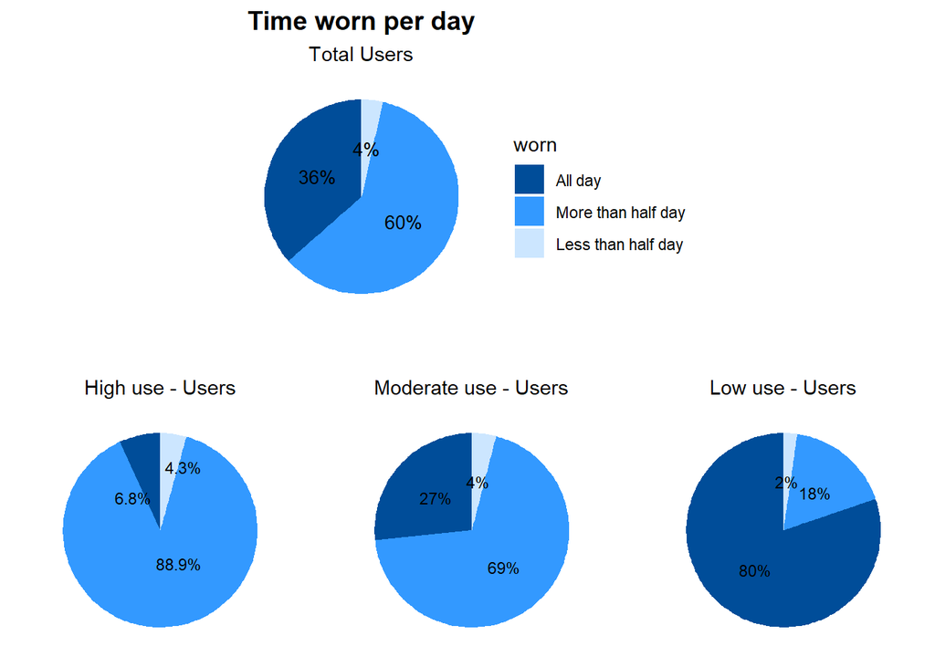

```r
ggarrange(
  ggplot(minutes_worn_percent, aes(x="",y=total_percent, fill=worn)) +
  geom_bar(stat = "identity", width = 1)+
  coord_polar("y", start=0)+
  theme_minimal()+
  theme(axis.title.x= element_blank(),
        axis.title.y = element_blank(),
        panel.border = element_blank(),
        panel.grid = element_blank(),
        axis.ticks = element_blank(),
        axis.text.x = element_blank(),
        plot.title = element_text(hjust = 0.5, size=14, face = "bold"),
        plot.subtitle = element_text(hjust = 0.5)) +
    scale_fill_manual(values = c("#004d99", "#3399ff", "#cce6ff"))+
  geom_text(aes(label = labels),
            position = position_stack(vjust = 0.5), size = 3.5)+
  labs(title="Time worn per day", subtitle = "Total Users"),
  ggarrange(
  ggplot(minutes_worn_highuse, aes(x="",y=total_percent, fill=worn)) +
  geom_bar(stat = "identity", width = 1)+
  coord_polar("y", start=0)+
  theme_minimal()+
  theme(axis.title.x= element_blank(),
        axis.title.y = element_blank(),
        panel.border = element_blank(),
        panel.grid = element_blank(),
        axis.ticks = element_blank(),
        axis.text.x = element_blank(),
        plot.title = element_text(hjust = 0.5, size=14, face = "bold"),
        plot.subtitle = element_text(hjust = 0.5),
        legend.position = "none")+
    scale_fill_manual(values = c("#004d99", "#3399ff", "#cce6ff"))+
  geom_text_repel(aes(label = labels),
            position = position_stack(vjust = 0.5), size = 3)+
  labs(title="", subtitle = "High use - Users"),
  ggplot(minutes_worn_moduse, aes(x="",y=total_percent, fill=worn)) +
  geom_bar(stat = "identity", width = 1)+
  coord_polar("y", start=0)+
  theme_minimal()+
  theme(axis.title.x= element_blank(),
        axis.title.y = element_blank(),
        panel.border = element_blank(),
        panel.grid = element_blank(),
        axis.ticks = element_blank(),
        axis.text.x = element_blank(),
        plot.title = element_text(hjust = 0.5, size=14, face = "bold"),
        plot.subtitle = element_text(hjust = 0.5),
        legend.position = "none") +
    scale_fill_manual(values = c("#004d99", "#3399ff", "#cce6ff"))+
  geom_text(aes(label = labels),
            position = position_stack(vjust = 0.5), size = 3)+
  labs(title="", subtitle = "Moderate use - Users"),
  ggplot(minutes_worn_lowuse, aes(x="",y=total_percent, fill=worn)) +
  geom_bar(stat = "identity", width = 1)+
  coord_polar("y", start=0)+
  theme_minimal()+
  theme(axis.title.x= element_blank(),
        axis.title.y = element_blank(),
        panel.border = element_blank(),
        panel.grid = element_blank(),
        axis.ticks = element_blank(),
        axis.text.x = element_blank(),
        plot.title = element_text(hjust = 0.5, size=14, face = "bold"),
        plot.subtitle = element_text(hjust = 0.5),
        legend.position = "none") +
    scale_fill_manual(values = c("#004d99", "#3399ff", "#cce6ff"))+
  geom_text(aes(label = labels),
            position = position_stack(vjust = 0.5), size = 3)+
  labs(title="", subtitle = "Low use - Users"),
  ncol = 3),
  nrow = 2)
```

# 5 Insights, Conclusions and Recomendations

As said at the beginning, data sets used for this analysis lack information about the demographic, sample size is pretty small and data is not recent. Considering that there are some interesting insights to be taken from the analysis of those data sets but it is recommended to analyse data gathered directly from Bellabeat users.

## 5.2 Recomendations

We can see that the biggest issue is the motivation to met step goals regularly and to track progress on a daily basis. Expecting same trends after Bellabeat users activity analysis below steps can be undertaken:

1. Award system can be made to motivate new users to meet the minimal goals of 10000 steps and 7 ours of sleep (i.e. discounts for Bellabeat products);
2. Integration of social platform such as forum or board, for users to motivate each other and show their progress;
3. Adding notifications with links to motivational content and studies showing benefits of living active life and sleeping well.

All of the above can be advertised with an emphasis on the motivational aspect but not leaving out the scientific under layer. As we live in a digital era, where platforms like Youtube, Twitter and TiTok are the biggest source of information, a combination of motivational influencers and science propagators can be used to achieve that goal.